# Визуализация данных

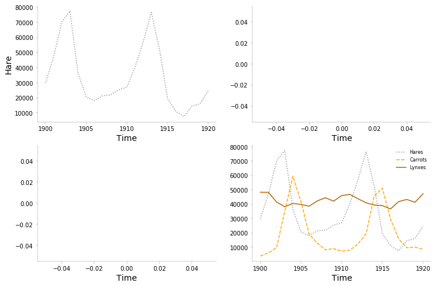

```python
fig, ax1= plt.subplots(2, 2, figsize=(12,8))

for x in range(2):
    for y in range(2):
        ax1[x][y].set_xlabel('Time', fontsize=14)
        ax1[x][y].locator_params(integer=True)
        ax1[x][y].spines['right'].set_visible(False)
        ax1[x][y].spines['top'].set_visible(False)
        ax1[x][y].xaxis.set_tick_params(width=0.2)
        ax1[x][y].yaxis.set_tick_params(width=0.2)
        for axis in ['top','bottom','left','right']:
            ax1[x][y].spines[axis].set_linewidth(0.2)


ax1[0][0].plot(data.year, data.hare, color='#8c92ac', ls = ':')
ax1[0][0].set_ylabel('Hare', fontsize=14)

ax1[1][1].plot(data.year, data.hare, label = 'Hares', color='#8c92ac', ls = ':'); # here the color is specified with three numbers
ax1[1][1].plot(data.year, data.lynx, label = 'Carrots', color='#ffa500', ls = '--'); # here the color is specified with three numbers
ax1[1][1].plot(data.year, data.carrot, label = 'Lynxes', color='#b06500', ls = '-'); # here the color is specified with three numbers
ax1[1][1].legend(loc=1, fontsize=8, frameon=False) # upper left corner
```

```python
fig.savefig("my_new_plot.png")
```

```python
os.getcwd()
```

```
'C:\\Users\\Rogov\\Desktop\\Data'
```

```python
df = pd.read_csv('crimeRatesByState2005.tsv',header=0,sep='\t')
```

```python
df.head()
```

|  | state | murder | Forcible_rate | Robbery | aggravated_assult | burglary | larceny_theft | motor_vehicle_theft | population |
| --- | --- | --- | --- | --- | --- | --- | --- | --- | --- |
| 0 | Alabama | 8.2 | 34.3 | 141.4 | 247.8 | 953.8 | 2650.0 | 288.3 | 4627851 |
| 1 | Alaska | 4.8 | 81.1 | 80.9 | 465.1 | 622.5 | 2599.1 | 391.0 | 686293 |
| 2 | Arizona | 7.5 | 33.8 | 144.4 | 327.4 | 948.4 | 2965.2 | 924.4 | 6500180 |
| 3 | Arkansas | 6.7 | 42.9 | 91.1 | 386.8 | 1084.6 | 2711.2 | 262.1 | 2855390 |
| 4 | California | 6.9 | 26.0 | 176.1 | 317.3 | 693.3 | 1916.5 | 712.8 | 36756666 |

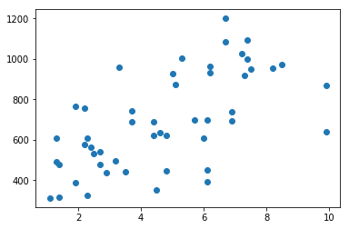

```python
fig, ax= plt.subplots(1, 1)
sc=plt.scatter(df['murder'], df['burglary'])
```

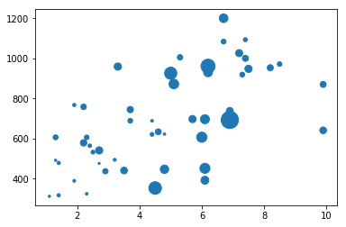

```python
fig, ax= plt.subplots(1, 1)
sc=plt.scatter(df['murder'], df['burglary'], s=df['population']/100000)
```

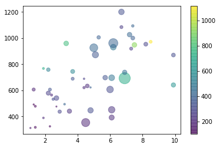

```python
fig, ax= plt.subplots(1, 1)
sc=plt.scatter(df['murder'], df['burglary'], s=df['population']/100000, c=df['motor_vehicle_theft'], alpha=0.5,cmap=plt.cm.get_cmap('viridis') )
plt.colorbar(sc)
```

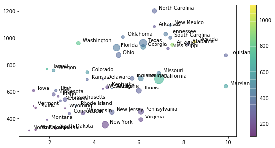

```python
fig, ax = plt.subplots(1, 1, figsize=(10,5))
plt.scatter(df['murder'], df['burglary'], s=df['population']/100000, c=df['motor_vehicle_theft'], alpha=0.5, cmap=plt.cm.get_cmap('viridis'))
state_names = df['state']
state_data = df[df.columns[1:]]

for i in range(len(state_names)):
    ax.annotate(state_names[i], (state_data.loc[i,"murder"]+0.2, state_data.loc[i,'burglary']+10))
plt.colorbar()
```

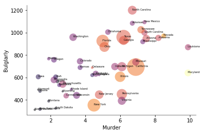

```python
fig, ax = plt.subplots()

ax.scatter(df['murder'], df['burglary'], s = np.array(df['population']) / 30000, c = df['Robbery'], cmap = 'inferno', alpha = 0.5, linewidth = 0)

ax.spines['right'].set_visible(False)
ax.spines['top'].set_visible(False)

ax.yaxis.set_ticks_position('left')
ax.xaxis.set_ticks_position('bottom')

ax.spines['left'].set_linewidth(0.5)
ax.spines['bottom'].set_linewidth(0.5)

ax.set_xlabel('Murder', fontsize = 10)
ax.set_ylabel('Bulglarly', fontsize = 10)

for i, state in enumerate(df['state']):
    ax.annotate(state, (df['murder'][i],df['burglary'][i]), fontsize = 5)
```

```python
url = 'https://python-graph-gallery.com/wp-content/uploads/gapminderData.csv'
data = pd.read_csv(url)
```

```python
data.head()
```

|  | country | year | pop | continent | lifeExp | gdpPercap |
| --- | --- | --- | --- | --- | --- | --- |
| 0 | Afghanistan | 1952 | 8425333.0 | Asia | 28.801 | 779.445314 |
| 1 | Afghanistan | 1957 | 9240934.0 | Asia | 30.332 | 820.853030 |
| 2 | Afghanistan | 1962 | 10267083.0 | Asia | 31.997 | 853.100710 |
| 3 | Afghanistan | 1967 | 11537966.0 | Asia | 34.020 | 836.197138 |
| 4 | Afghanistan | 1972 | 13079460.0 | Asia | 36.088 | 739.981106 |

```python
my_dpi=96
```

```python
data['continent']=pd.Categorical(data['continent'])
data.head()
```

|  | country | year | pop | continent | lifeExp | gdpPercap |
| --- | --- | --- | --- | --- | --- | --- |
| 0 | Afghanistan | 1952 | 8425333.0 | Asia | 28.801 | 779.445314 |
| 1 | Afghanistan | 1957 | 9240934.0 | Asia | 30.332 | 820.853030 |
| 2 | Afghanistan | 1962 | 10267083.0 | Asia | 31.997 | 853.100710 |
| 3 | Afghanistan | 1967 | 11537966.0 | Asia | 34.020 | 836.197138 |
| 4 | Afghanistan | 1972 | 13079460.0 | Asia | 36.088 | 739.981106 |

```
(355.1974801060595, 100000)
```

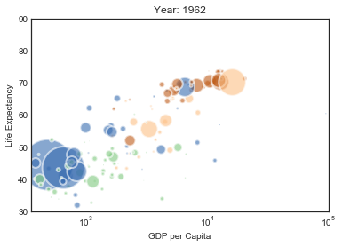

```python
tmp = data[data.year == 1962 ]
plt.scatter(tmp['gdpPercap'], tmp['lifeExp'], s=tmp['pop']/200000 , c=tmp['continent'].cat.codes, cmap="Accent", alpha=0.6, edgecolors="white", linewidth=2)
plt.xscale('log')
plt.xlabel("GDP per Capita")
plt.ylabel("Life Expectancy")
plt.title("Year: "+str(1962) )
plt.ylim(30, 90)
plt.xlim(0,100000)
```

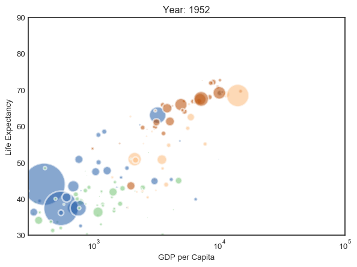

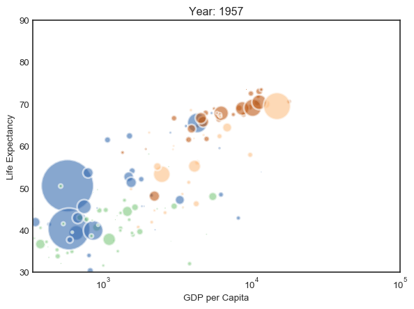

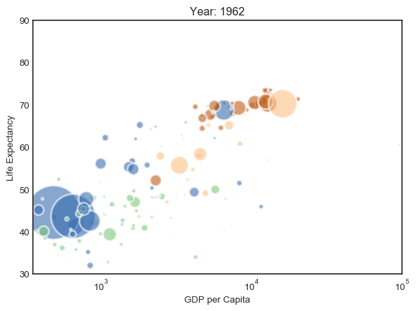

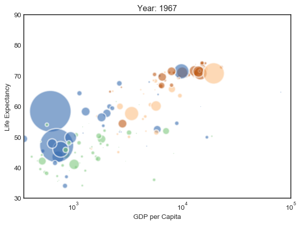

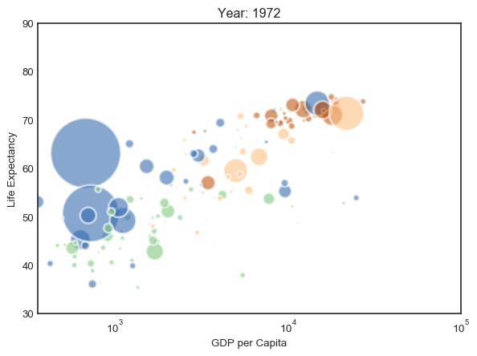

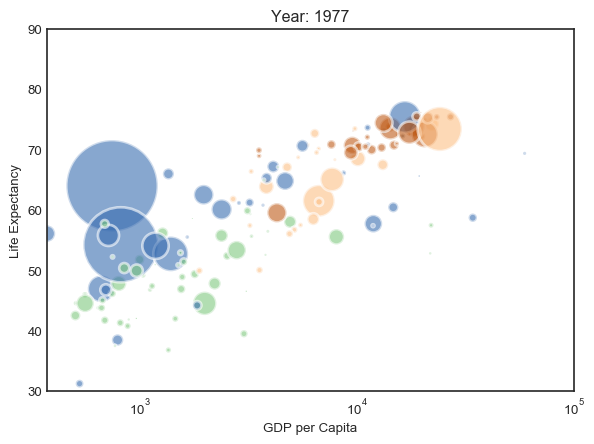

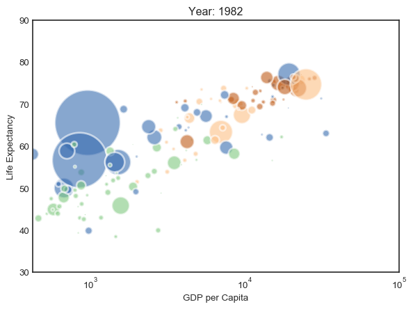

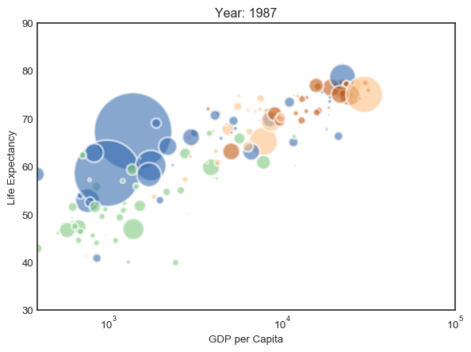

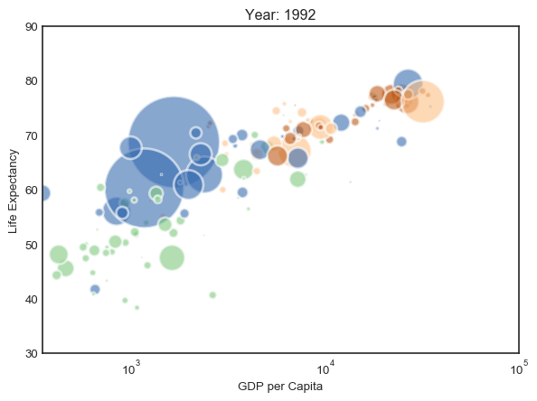

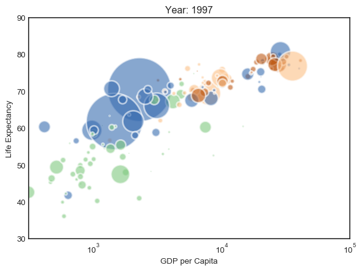

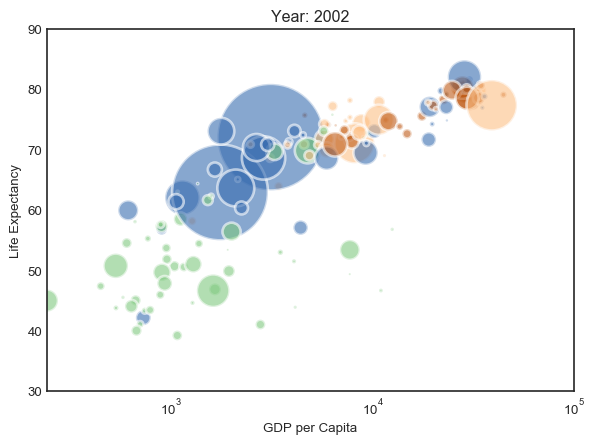

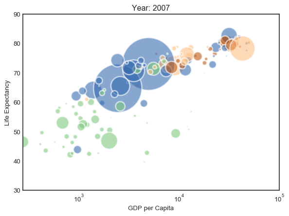

```python
# For each year:
for i in data.year.unique():

    # initialize a figure
    fig = plt.figure(figsize=(680/my_dpi, 480/my_dpi), dpi=my_dpi)

    # Change color with c and alpha. I map the color to the X axis value.
    tmp = data[data.year == i ]
    plt.scatter(tmp['gdpPercap'], tmp['lifeExp'], s=tmp['pop']/200000 , c=tmp['continent'].cat.codes, cmap="Accent", alpha=0.6, edgecolors="white", linewidth=2)

    plt.xscale('log')
    plt.xlabel("GDP per Capita")
    plt.ylabel("Life Expectancy")
    plt.title("Year: "+str(i) )
    plt.ylim(30, 90)
    plt.xlim(0,100000)

    # Save it
    filename='Gapminder_step'+str(i)+'.png'
    plt.savefig(filename, dpi=96)
    plt.gca()
```

```python
# импортируем библиотеки
%matplotlib inline

import numpy as np  # библиотека для работы с числами, пригодится для преобразований
import pandas as pd
import matplotlib.pyplot as plt  # библиотека для визуализации
import seaborn as sns            # библиотека для визуализации
```

[output not shown]

```python
df = pd.read_csv('filmdeathcounts.csv')
```

```python
df.head()
```

|  | Film | Year | Body_Count | MPAA_Rating | Genre | Director | Length_Minutes | IMDB_Rating |
| --- | --- | --- | --- | --- | --- | --- | --- | --- |
| 0 | 24 Hour Party People | 2002 | 7 | R | Biography\|Comedy\|Drama\|Music | Michael Winterbottom | 117 | 7.3 |
| 1 | 28 Days Later | 2002 | 53 | R | Horror\|Sci-Fi\|Thriller | Danny Boyle | 113 | 7.6 |
| 2 | 28 Weeks Later | 2007 | 212 | R | Horror\|Sci-Fi\|Thriller | Juan Carlos Fresnadillo | 100 | 7.0 |
| 3 | 30 Days of Night | 2007 | 67 | R | Horror\|Thriller | David Slade | 113 | 6.6 |
| 4 | 300 | 2007 | 600 | R | Action\|Fantasy\|History\|War | Zack Snyder | 117 | 7.7 |

Давайте добавим две новых переменных: счетчик фильмов (понадобится позже при группировках, для всех фильмов равен 1). И переменная, измеряющая количество трупов в минуту экранного времени :)

```python
df['Film_Count'] = 1
df['Body_Count_Min'] = df['Body_Count'] / df['Length_Minutes'].astype(float)
df.head()
```

|  | Film | Year | Body_Count | MPAA_Rating | Genre | Director | Length_Minutes | IMDB_Rating | Film_Count | Body_Count_Min |
| --- | --- | --- | --- | --- | --- | --- | --- | --- | --- | --- |
| 0 | 24 Hour Party People | 2002 | 7 | R | Biography\|Comedy\|Drama\|Music | Michael Winterbottom | 117 | 7.3 | 1 | 0.059829 |
| 1 | 28 Days Later | 2002 | 53 | R | Horror\|Sci-Fi\|Thriller | Danny Boyle | 113 | 7.6 | 1 | 0.469027 |
| 2 | 28 Weeks Later | 2007 | 212 | R | Horror\|Sci-Fi\|Thriller | Juan Carlos Fresnadillo | 100 | 7.0 | 1 | 2.120000 |
| 3 | 30 Days of Night | 2007 | 67 | R | Horror\|Thriller | David Slade | 113 | 6.6 | 1 | 0.592920 |
| 4 | 300 | 2007 | 600 | R | Action\|Fantasy\|History\|War | Zack Snyder | 117 | 7.7 | 1 | 5.128205 |

В прошлые разы мы с вами смотрели, как группировать таблицы по паре параметров и считать описательные статистики. В pandas мы можем создавать агрегированные таблицы (суммирующие, пивотальные - вы можете знать их под этими именами). Давайте сгруппируем фильмы по году и для каждой колонки посчитаем сумму, среднее и медиану.

```python
group_year = df.groupby('Year').agg([np.mean, np.median, sum])
group_year.tail()
```

| Year | Body_Count mean | Body_Count median | Body_Count sum | Length_Minutes mean | Length_Minutes median | Length_Minutes sum | IMDB_Rating mean | IMDB_Rating median | IMDB_Rating sum | Film_Count mean | Film_Count median | Film_Count sum | Body_Count_Min mean | Body_Count_Min median | Body_Count_Min sum |
| --- | --- | --- | --- | --- | --- | --- | --- | --- | --- | --- | --- | --- | --- | --- | --- |
| 2007 | 85.312500 | 45.5 | 4095 | 114.062500 | 111.0 | 5475 | 6.829167 | 7.00 | 327.8 | 1 | 1 | 48 | 0.749838 | 0.366966 | 35.992220 |
| 2008 | 68.653846 | 37.0 | 1785 | 109.615385 | 108.5 | 2850 | 6.573077 | 6.65 | 170.9 | 1 | 1 | 26 | 0.635468 | 0.371208 | 16.522174 |
| 2009 | 55.000000 | 59.0 | 605 | 112.272727 | 110.0 | 1235 | 6.845455 | 6.60 | 75.3 | 1 | 1 | 11 | 0.518937 | 0.385621 | 5.708305 |
| 2010 | 129.750000 | 126.0 | 519 | 115.750000 | 111.0 | 463 | 7.250000 | 7.25 | 29.0 | 1 | 1 | 4 | 1.132110 | 1.005280 | 4.528441 |
| 2013 | 156.000000 | 156.0 | 156 | 119.000000 | 119.0 | 119 | 6.500000 | 6.50 | 6.5 | 1 | 1 | 1 | 1.310924 | 1.310924 | 1.310924 |

```python
df_bc = pd.DataFrame({'mean_value': group_year['Body_Count']['mean'],
                      'median_value': group_year['Body_Count']['median']})

df_bc_min = pd.DataFrame({'mean_value': group_year['Body_Count_Min']['mean'],
                          'median_value': group_year['Body_Count_Min']['median']})
```

```python
df_bc.head()
```

| Year | mean_value | median_value |
| --- | --- | --- |
| 1949 | 4.0 | 4.0 |
| 1954 | 57.5 | 57.5 |
| 1957 | 67.0 | 67.0 |
| 1959 | 7.0 | 7.0 |
| 1960 | 55.0 | 55.0 |

```python
df_bc_min.head()
```

| Year | mean_value | median_value |
| --- | --- | --- |
| 1949 | 0.038462 | 0.038462 |
| 1954 | 0.425822 | 0.425822 |
| 1957 | 0.761364 | 0.761364 |
| 1959 | 0.088608 | 0.088608 |
| 1960 | 0.429688 | 0.429688 |

```python
plt.style.available
```

```
['bmh',
 'classic',
 'dark_background',
 'fast',
 'fivethirtyeight',
 'ggplot',
 'grayscale',
 'seaborn-bright',
 'seaborn-colorblind',
 'seaborn-dark-palette',
 'seaborn-dark',
 'seaborn-darkgrid',
 'seaborn-deep',
 'seaborn-muted',
 'seaborn-notebook',
 'seaborn-paper',
 'seaborn-pastel',
 'seaborn-poster',
 'seaborn-talk',
 'seaborn-ticks',
 'seaborn-white',
 'seaborn-whitegrid',
 'seaborn',
 'Solarize_Light2',
 'tableau-colorblind10',
 '_classic_test']
```

```python
# plt.style.use('seaborn-dark-palette')
```

```python
sns.set_style("whitegrid")
```

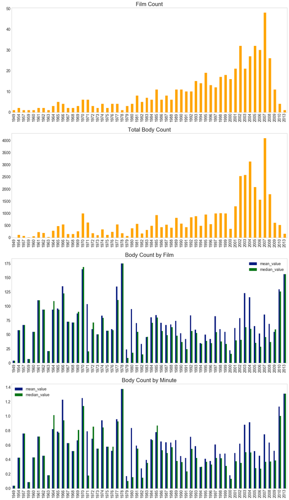

```python
fig, axes = plt.subplots(nrows=4, ncols=1, figsize=(16, 30))

group_year['Film_Count']['sum'].plot(kind='bar', ax=axes[0], color = '#ffa500')
axes[0].set_title('Film Count')

group_year['Body_Count']['sum'].plot(kind='bar', ax=axes[1], color = '#ffa500')
axes[1].set_title('Total Body Count')

df_bc.plot(kind='bar', ax=axes[2])
axes[2].set_title('Body Count by Film')

df_bc_min.plot(kind='bar', ax=axes[3])
axes[3].set_title('Body Count by Minute')

for i in range(4):
    axes[i].set_xlabel('', visible=False)
    axes[i].grid(b = False)
```

```python
df.head()
```

|  | Film | Year | Body_Count | MPAA_Rating | Genre | Director | Length_Minutes | IMDB_Rating | Film_Count | Body_Count_Min |
| --- | --- | --- | --- | --- | --- | --- | --- | --- | --- | --- |
| 0 | 24 Hour Party People | 2002 | 7 | R | Biography\|Comedy\|Drama\|Music | Michael Winterbottom | 117 | 7.3 | 1 | 0.059829 |
| 1 | 28 Days Later | 2002 | 53 | R | Horror\|Sci-Fi\|Thriller | Danny Boyle | 113 | 7.6 | 1 | 0.469027 |
| 2 | 28 Weeks Later | 2007 | 212 | R | Horror\|Sci-Fi\|Thriller | Juan Carlos Fresnadillo | 100 | 7.0 | 1 | 2.120000 |
| 3 | 30 Days of Night | 2007 | 67 | R | Horror\|Thriller | David Slade | 113 | 6.6 | 1 | 0.592920 |
| 4 | 300 | 2007 | 600 | R | Action\|Fantasy\|History\|War | Zack Snyder | 117 | 7.7 | 1 | 5.128205 |

```python
df_film = df.set_index('Film')
df_film.head()
```

| Film | Year | Body_Count | MPAA_Rating | Genre | Director | Length_Minutes | IMDB_Rating | Film_Count | Body_Count_Min |
| --- | --- | --- | --- | --- | --- | --- | --- | --- | --- |
| 24 Hour Party People | 2002 | 7 | R | Biography\|Comedy\|Drama\|Music | Michael Winterbottom | 117 | 7.3 | 1 | 0.059829 |
| 28 Days Later | 2002 | 53 | R | Horror\|Sci-Fi\|Thriller | Danny Boyle | 113 | 7.6 | 1 | 0.469027 |
| 28 Weeks Later | 2007 | 212 | R | Horror\|Sci-Fi\|Thriller | Juan Carlos Fresnadillo | 100 | 7.0 | 1 | 2.120000 |
| 30 Days of Night | 2007 | 67 | R | Horror\|Thriller | David Slade | 113 | 6.6 | 1 | 0.592920 |
| 300 | 2007 | 600 | R | Action\|Fantasy\|History\|War | Zack Snyder | 117 | 7.7 | 1 | 5.128205 |

```python
df_film.sort_values(by=['Body_Count'])['Body_Count'].tail(10)
```

```
Film
King Arthur                              378
Windtalkers                              389
Lord of the Rings: Two Towers            468
A Fistful of Dynamite                    471
The Last Samurai                         558
Troy                                     572
Tae Guk Gi: The Brotherhood of War       590
300                                      600
Kingdom of Heaven                        610
Lord of the Rings: Return of the King    836
Name: Body_Count, dtype: int64
```

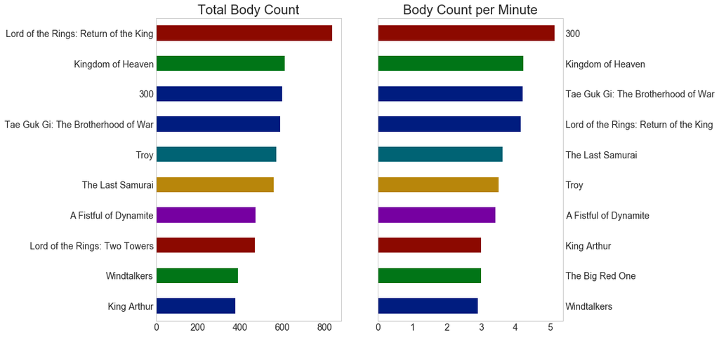

```python
fig, axes = plt.subplots(nrows=1, ncols=2, figsize=(10, 8))

bc = df_film.sort_values(by=['Body_Count'])['Body_Count'].tail(10)
bc.plot(kind='barh', ax=axes[0])
axes[0].set_title('Total Body Count')

bc_min = df_film.sort_values(by=['Body_Count_Min'])['Body_Count_Min'].tail(10)
bc_min.plot(kind='barh', ax=axes[1])
axes[1].set_title('Body Count per Minute')
axes[1].yaxis.set_ticks_position('right')

for i in range(2):
    axes[i].set_ylabel('', visible=False)
    axes[i].grid('False')
```

# Most violent directors

```python
df[df['Director'].apply(lambda x: -1 != x.find('|'))].head()
```

|  | Film | Year | Body_Count | MPAA_Rating | Genre | Director | Length_Minutes | IMDB_Rating | Film_Count | Body_Count_Min |
| --- | --- | --- | --- | --- | --- | --- | --- | --- | --- | --- |
| 26 | Aliens vs. Predator: Requiem | 2007 | 5 | R | Action\|Horror\|Sci-Fi\|Thriller | Colin Strause\|Greg Strause | 94 | 4.7 | 1 | 0.053191 |
| 38 | Aqua Teen Hunger Force Colon Movie Film for Th... | 2007 | 67 | R | Animation\|Action\|Adventure | Matt Maiellaro\|Dave Willis | 86 | 6.8 | 1 | 0.779070 |
| 46 | Bangkok Dangerous | 2008 | 38 | R | Action\|Crime\|Thriller | Oxide Pang Chun\|Danny Pang | 99 | 5.4 | 1 | 0.383838 |
| 47 | Barton Fink | 1991 | 3 | R | Drama\|Mystery | Joel Coen\|Ethan Coen | 116 | 7.7 | 1 | 0.025862 |
| 83 | City of God | 2002 | 60 | R | Crime\|Drama | Fernando Meirelles\|Katia Lund | 130 | 8.7 | 1 | 0.461538 |

```python
def expand_col(df_src, col, sep='|'):
    di = {}
    idx = 0
    for i in df_src.iterrows():
        d = i[1]
        names = d[col].split(sep)
        for name in names:
            # operate on a copy to not overwrite previous director names
            c = d.copy()
            c[col] = name
            di[idx] = c
            idx += 1

    df_new = pd.DataFrame(di).transpose()
    # these two columns are not recognized as numeric
    df_new['Body_Count'] = df_new['Body_Count'].astype(float)
    df_new['Body_Count_Min'] = df_new['Body_Count_Min'].astype(float)

    return df_new
```

```python
bc_sum = df_dir.groupby('Director').sum().sort_values(by=['Body_Count']).tail(10)
bc_sum
```

| Director | Body_Count | Body_Count_Min |
| --- | --- | --- |
| Je-kyu Kang | 1770.0 | 12.642857 |
| Uwe Boll | 1818.0 | 16.766390 |
| Steven Spielberg | 1824.0 | 12.095150 |
| Antoine Fuqua | 2015.0 | 16.781665 |
| Wolfgang Petersen | 2095.0 | 15.862454 |
| Zack Snyder | 3155.0 | 27.126865 |
| Ridley Scott | 3562.0 | 24.768490 |
| Edward Zwick | 3567.0 | 24.760846 |
| Peter Jackson | 4502.0 | 24.186545 |
| John Woo | 5127.0 | 42.306633 |

```python
bc_mean = df_dir.groupby('Director').agg(np.mean).sort_values(by=['Body_Count_Min']).tail(10)
bc_mean
```

| Director | Body_Count | Body_Count_Min |
| --- | --- | --- |
| Randall Wallace | 305.000000 | 2.210145 |
| King Hu | 213.000000 | 2.242105 |
| Sylvester Stallone | 225.000000 | 2.327828 |
| Kevin Munroe | 206.000000 | 2.367816 |
| Zack Snyder | 286.818182 | 2.466079 |
| Edward Zwick | 356.700000 | 2.476085 |
| Katja von Garnier | 256.000000 | 2.612245 |
| Simon Hunter | 310.000000 | 2.792793 |
| Samuel Fuller | 338.000000 | 2.991150 |
| Je-kyu Kang | 590.000000 | 4.214286 |

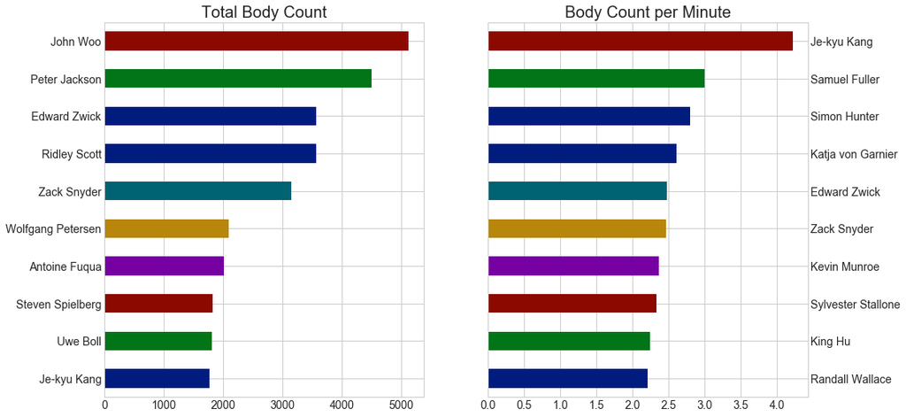

```python
fig, axes = plt.subplots(nrows=1, ncols=2, figsize=(14, 8))

bc_sum['Body_Count'].plot(kind='barh', ax=axes[0])
axes[0].set_title('Total Body Count')

bc_mean['Body_Count_Min'].plot(kind='barh', ax=axes[1])
axes[1].set_title('Body Count per Minute')
axes[1].yaxis.set_ticks_position('right')

for i in range(2):
    axes[i].set_ylabel('', visible=False)
```

# by genre

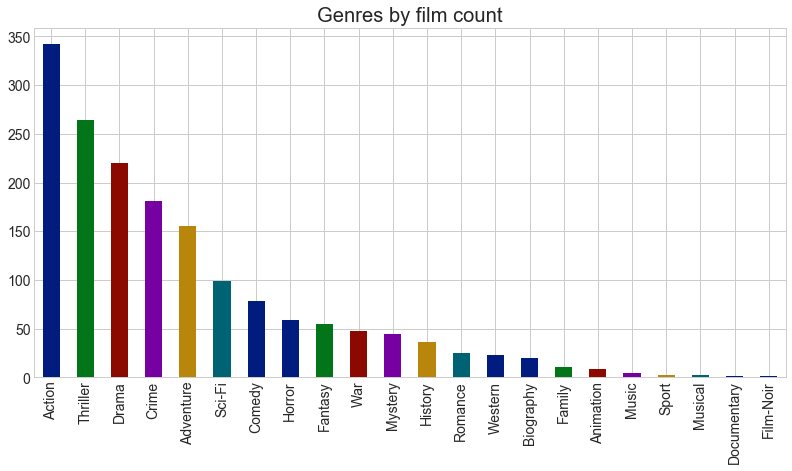

```python
df_dir['Genre'].value_counts().plot(kind='bar', figsize=(12, 6), title='Genres by film count')
```

```python
bc_mean = df_dir.groupby('Genre').agg(np.mean).sort_values(by=['Body_Count_Min'], ascending=False)
```

[output not shown]

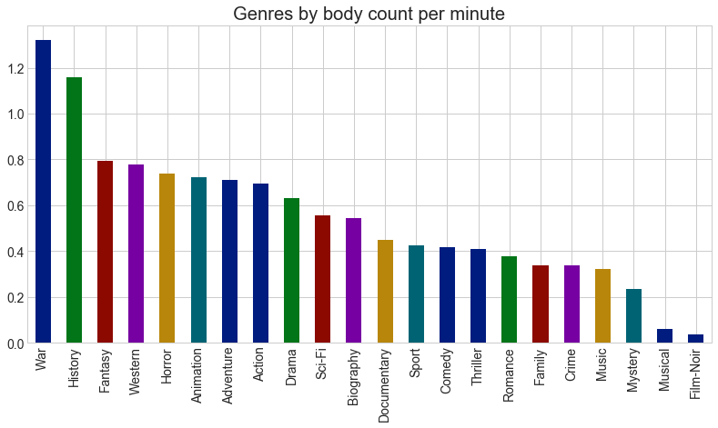

```python
ax = bc_mean['Body_Count_Min'].plot(kind='bar', figsize=(12, 6), title='Genres by body count per minute')
ax.set_xlabel('', visible=False)
```

# Rankings

```python
df['MPAA_Rating'].value_counts()
```

```
R           338
PG-13       118
PG           35
Unrated      28
Approved      9
M             5
X             4
GP            4
G             3
NR            1
Name: MPAA_Rating, dtype: int64
```

```python
df['Body_Count_Min'].max()
```

```
5.128205128205129
```

```
Text(0,0.5,'Body count per minute')
```

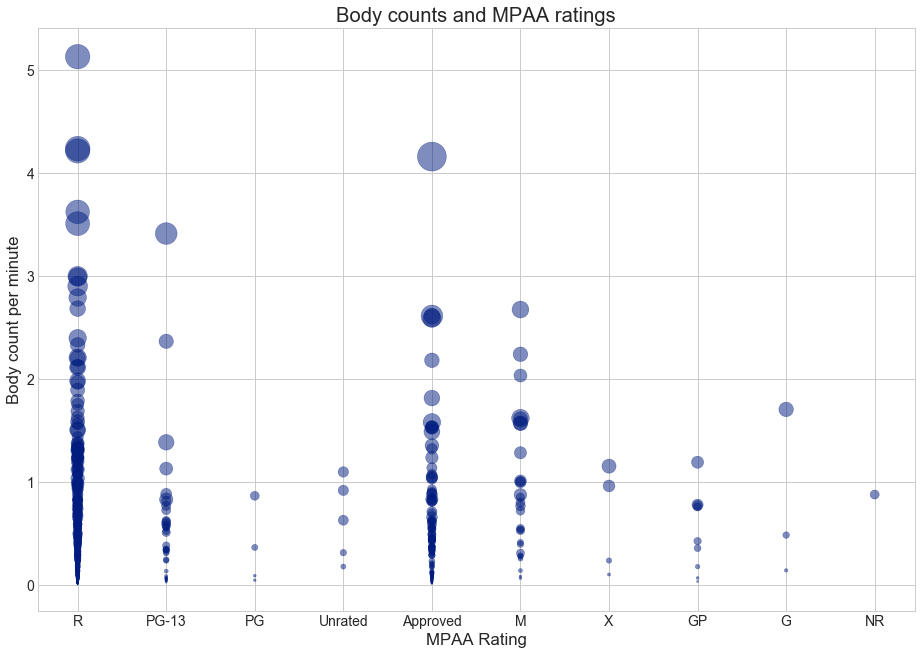

```python
fig, ax = plt.subplots(figsize=(14, 10))
ax.scatter(df['MPAA_Rating'], df['Body_Count_Min'], s=df['Body_Count'], alpha=.5)
ax.set_title('Body counts and MPAA ratings')
ax.set_xlabel('MPAA Rating')
ax.set_xticks(rating_index)
ax.set_xticklabels(rating_names)
ax.set_ylabel('Body count per minute')
```

```python
bc_top.reset_index()
```

|  | index | Film | Year | Body_Count | MPAA_Rating | Genre | Director | Length_Minutes | IMDB_Rating | Film_Count | Body_Count_Min |
| --- | --- | --- | --- | --- | --- | --- | --- | --- | --- | --- | --- |
| 0 | 241 | Lord of the Rings: Return of the King | 2003 | 836 | PG-13 | Action\|Adventure\|Fantasy | Peter Jackson | 201 | 8.9 | 1 | 4.159204 |
| 1 | 217 | Kingdom of Heaven | 2005 | 610 | R | Action\|Adventure\|Drama\|History\|War | Ridley Scott | 144 | 7.1 | 1 | 4.236111 |
| 2 | 4 | 300 | 2007 | 600 | R | Action\|Fantasy\|History\|War | Zack Snyder | 117 | 7.7 | 1 | 5.128205 |

```python
bc_top = df.sort_values('Body_Count', ascending=False)[:3].reset_index()
annotations = []
for r in range(len(bc_top)):
    annotations.append([bc_top['Film'][r], bc_top['IMDB_Rating'][r], bc_top['Body_Count_Min'][r]])
annotations
```

```
[['Lord of the Rings: Return of the King', 8.9, 4.159203980099503],
 ['Kingdom of Heaven', 7.1, 4.236111111111111],
 ['300', 7.7, 5.128205128205129]]
```

[output not shown]

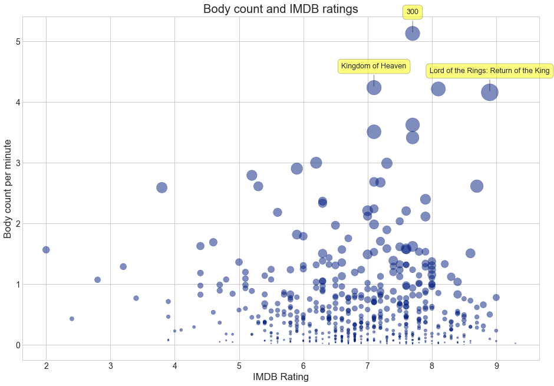

```python
fig, ax = plt.subplots(figsize=(14, 10))
ax.scatter(df['IMDB_Rating'], df['Body_Count_Min'], s=df['Body_Count'], alpha=.5)
ax.set_title('Body count and IMDB ratings')
ax.set_xlabel('IMDB Rating')
ax.set_ylabel('Body count per minute')

for annotation, x, y in annotations:
    plt.annotate(
        annotation,
        xy=(x, y),
        xytext=(0, 30),
        textcoords='offset points',
        ha='center',
        va='bottom',
        size=12.5,
        bbox=dict(boxstyle='round,pad=0.5', fc='yellow', alpha=0.5),
        arrowprops=dict(arrowstyle='-'))
```